# Description

### Course STAT292 Statistical Computing II

#### Semester Spring 2017

#### Content Sorting and Statistics

# 1 Selection Sort

## 1.1 Find the minimum of an Array

This function takes a $size \ n$ array and returns the index of the minimum.

```r
find_min = function(myArray){

  n = length(myArray) # get the length of the array

  min_ind = 1 # suppose the first element in the array is the minimum

  for(i in 1:n){
    if(myArray[min_ind] > myArray[i]){
      min_ind = i #traverse through the vector and change the min_ind if the current minimum is greater than current element
    }
  }

  return(min_ind)
}
```

Demo:

```r
X = c(2, 3, 7, 10, -4, 1)
find_min(X)
```

5

Since -4 is the minimum and it is the 5<sup>th</sup> element of the array, function returns 5. Equivelently, one can use $which.min$ function in R. It is a built-in function.

```r
which.min(X)
```

5

## 1.2 Selection Sort Algorithm

Suppose we want to sort $X$ which is a $size \ n$ vector

- **1** Create an empty vector $Y$
- **2** Find the minimum of $X$ call it $m$
- **3** Discard $m$ from the $X$
- **4** Append $m$ to $Y$
- **5** Follow step 2, 3 and 4 until $X$ become an empty list

## 1.3 Implementation of Selection Sort in $R$

Suppose, $$x \sim N(\mu = 0, \sigma = 10)$$

```r
n = 100 # Suppose our sample size is 100
X = rnorm(n, 0, 10) # Sample 100 numbers that are coming from N(0, 10)

selection_sort = function(X){

    n = length(X)

    Y = numeric(0) #step 1
    for(i in 1:n){
        cur_min_index = find_min(X) # step 2
        m = X[cur_min_index] # step 2

        X = X[-cur_min_index] # step 3
        Y = c(Y, m) # step 4
    }

    return(Y)
}

print(selection_sort(X)) #sorted array
```

```
  [1] -22.80911449 -21.79618865 -15.80964746 -15.65935717 -14.76709081
  [6] -14.74553250 -13.73643595 -13.23446681 -13.21877101 -12.92602683
 [11] -11.16723645 -10.22713939 -10.17732844 -10.03651458  -9.57580326
 [16]  -9.32278521  -8.59024614  -8.35685167  -7.70072521  -7.65111260
 [21]  -7.52298972  -6.73828801  -6.48557258  -6.35836582  -6.20273110
 [26]  -5.58411880  -5.34743676  -5.17779055  -5.00902442  -4.75431089
 [31]  -4.74152066  -4.66464813  -4.56006066  -4.17030822  -4.13002077
 [36]  -3.94824429  -3.82032468  -3.54696696  -3.45724284  -3.34082348
 [41]  -3.01166721  -2.50308243  -2.33843183  -2.29695901  -2.03434348
 [46]  -1.29138541  -1.21947023  -1.12704851  -0.89552132  -0.71747840
 [51]  -0.27286629  -0.08778446  -0.08035962  -0.02867410   0.07707075
 [56]   0.29193759   0.91098772   1.04576858   1.15543446   1.76574999
 [61]   2.05694544   2.13722724   2.31162879   2.87916017   2.95890304
 [66]   3.03119427   3.11528644   3.79268072   3.87711083   4.07200750
 [71]   4.15961744   4.50613574   4.92615629   5.00032541   5.30691134
 [76]   5.52657687   6.26467189   6.41204874   6.57827409   6.79932236
 [81]   6.90167333   7.07210902   7.77823567   8.74596915   8.79581689
 [86]   8.93663893   9.14567992   9.22651527  10.20475242  12.44679970
 [91]  12.56672437  14.24002647  15.07431515  15.94081698  15.95556476
 [96]  16.04009576  17.85547912  22.49512019  23.11691478  23.80174334
```

**Note:** We returned index of the minimum not the value of it. Because, it is easier to discard an element from an array if we know its index value (index value is basically the location of the number in an array).

# 2 Quick Sort

## 2.1 Recursion

To understand the quick sort algorithm, first we need to know recursion. Recursion in computer science is a method where the solution to a problem depends on solutions to smaller instances of the same problem. Consider above example, selection sort. We iteratively taking the minimum of an array while discarding an element from it. Everytime we are implementing the same solution to a smaller instance. Lets implement selection sort algorithm not with a for loop but with a recursive function.

### 2.1.1 Selection Sort via Recursion

```r
X = rnorm(10, 0, 10)

selection_sort_rec = function(X){

    if(length(X) == 1) return(X) # If there is only one element return itself. It is naturally the minimum of the set.

    min_index = find_min(X)
    return(c(X[min_index], selection_sort_rec(X[-min_index])))
}

print(selection_sort_rec(X))
```

```
 [1] -22.3804351  -3.3263968  -2.8899434  -0.6395356   4.8476809   6.2599037
 [7]   6.3877253   6.3974586  13.6220549  16.3858548
```

Above $selection\_sort$ function, all job is done at $return$ part. As you can see, returned value is a combination of two elements, one is the minimum of the array and other one is again a call of $selection\_sort$ function but without the minimum of the array. We partitioned the problem into small subsets.

### 2.1.2 Factorials via Recursion

Here is the generic application of recursion. Factorials!!!

Find n!

```r
factorial = function(n){
    if(n == 0) return(1)

    return(n* factorial(n-1))
}

print(factorial(0))
print(factorial(4))
print(factorial(10))
```

```
[1] 1
[1] 24
[1] 3628800
```

Recursion is basically a fuction that calls itself until a stopping rule. For example in factorial example stopping rule is $n=0$. When we reach zero, algorithm returns $1$. So it stops. Here is the mathematical representation of factorial example:
$$ f(n)=\left\{ \begin{array}{ll} n \ f(n-1), \ n \in(1,2,3, \dots)\\ 1, \ n = 0 \end{array} \right.$$

[Click here to watch a perfect explanation of recursion](https://www.youtube.com/watch?v=Mv9NEXX1VHc)

## 2.2 Quick Sort Algorithm

Suppose we want to sort $X$ which is a $size \ n$ vector

- **1** Select a random number in $X$, call it $m$
- **2** Create 2 sets, say $H$ and $L$. Store the numbers that are greater than $m$ in $H$ and lowers in $L$.
- **3** Store them in a vector Y with this order: Y = (L, m, H)
- **4** Repeat 1,2 and 3 for L and H until Y is sorted.

```r
quick_sort = function(x){

    n = length(unique(x)) # number of distinct elements

    #Two stopping rules
    if(n == 1) return(x) # If set has 1 unique element, return the set itself. eg: x = a, a, a or x = b.
    if(n == 0) return() # If set is empty return nothing

    pivot = sample(x, 1) #step 1
    H = x[which(x >= pivot)] #step 2 (we could put equality in both sides, it doesnt matter)
    L = x[which(x < pivot)] #step 2

    return(c(quick_sort(L), quick_sort(H))) #step 3 and 4

}
```

```r
X = c(1, 2, 4, 10, -2, 3, 3, 3, 1, -2, 10, 10, 2)
print(quick_sort(X))
```

```
 [1] -2 -2  1  1  2  2  3  3  3  4 10 10 10
```

[Here is a musical implementation of sorting algorithms](https://www.youtube.com/watch?v=kPRA0W1kECg). Here is the built-in implementation [sort function in R](https://stat.ethz.ch/R-manual/R-devel/library/base/html/sort.html). Their implementations are even quicker than quick sort.

# 3 Time Complexity of Sorting Algorithms and a naive example of Linear Models

Lets write a running time function for comparing algorithms.

```r
calc_time = function(sorting_func, X){
    #sorting_func: is basically function's itself
    #X is the array that is need to be sorted

    time_IS = proc.time() #proc.time() function gives current time and we store it in time_IS

    sorted = sorting_func(X) #here is the process

    time_IS = proc.time() - time_IS #we update time_IS by substracting from current time. It basicaly gives us elapsed time

    return(time_IS[3]) # 3rd element is the total time
}
```

```r
n = 1000
X = rnorm(n, 0, 10)
```

```r
totalTime = calc_time( selection_sort, X )
print(totalTime) #in seconds
```

```
elapsed
   0.56
```

```r
totalTime = calc_time( quick_sort, X )
print(totalTime) #in seconds
```

```
elapsed
    0.1
```

## 3.2 Visualization of complexity

In this task we are going to investigate how elapsed time changes when sample size changes. For this task we are going design our experiment as below:

```r
set.seed(1)
totalTime_SS = numeric(0) # array that stores elapsed time on selection_sort
totalTime_QS = numeric(0) # array that stores elapsed time on quick_sort

iterationNo = 5
n = c(250, 500, 1000, 2000, 4000)
n = round(rep(n, each = iterationNo))

for(i in 1:length(n)){

    X = rnorm(n[i], 0, 10)

    totalTime_SS = c(totalTime_SS, calc_time(selection_sort, X)) # append the next value
    totalTime_QS = c(totalTime_QS, calc_time(quick_sort, X)) # append the next value

}
```

```r
library(ggplot2)
```

We create below data.frame for ggplot. It accepts this type of data frames.

```r
df = data.frame(
    elapsed_time = c(totalTime_SS, totalTime_QS),
    algorithm_name = c(rep("Selection Sort", length(n)), rep("Quick Sort", length(n))),
    sample_size = rep(n, 2))
```

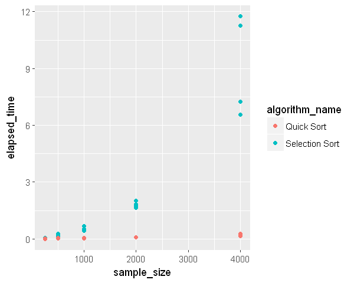

```r
options(repr.plot.width=5, repr.plot.height=4)
ggplot(df, aes(sample_size, elapsed_time)) +
geom_point(aes(colour = algorithm_name))
```

```r
df_mean = aggregate(df$elapsed_time, by = list(df$algorithm_name, df$sample_size), mean)
colnames(df_mean) = c("algorithm_name", "sample_size", "mean_elapsed_time")
df_mean
```

| algorithm_name | sample_size | mean_elapsed_time |
| --- | --- | --- |
| Quick Sort | 250 | 0.016 |
| Selection Sort | 250 | 0.050 |
| Quick Sort | 500 | 0.042 |
| Selection Sort | 500 | 0.176 |
| Quick Sort | 1000 | 0.038 |
| Selection Sort | 1000 | 0.496 |
| Quick Sort | 2000 | 0.084 |
| Selection Sort | 2000 | 1.808 |
| Quick Sort | 4000 | 0.210 |
| Selection Sort | 4000 | 8.818 |

Observe that when sample size doubles mean_elapsed_time of Quick Sort algorithm increase with a magnitude a litle more than itself. However the change in the Selection sort is not linear it is quadratically increasing.

## 3.3 Statistical Linear Model

We know elapsed time is a function of sample size. But we do not know the exact function. Suppose we do not know anything about algorithm analysis, we could analyse an algorithm via a statistical linear model. Here is a statistical model for elapsed time.

$$ t = g(n) + error, \ \ where \ n = sample\_size \ and \ t = elapsed\_time $$

We added the error term. Because when we put same $n$ we get different $t$'s. We could observe that from the plot in visualization part.

### 3.3.1 Linear Model for Selection Sort

n = 0 $\Rightarrow$ t = 0, naturally. So we construct a model without intercept. Suppose we fit a power model.

$$ t = \beta \ n^{k} +\epsilon $$

Here are 2 learnable parameters, namely $\beta$ and $k$. Assume $k = 2$ (one could apply $log$ transformation and fit a model to find $k$ but for the sake of simplicity, we are going to assume its value), and estimate $\beta$.

```r
SS = df[df$algorithm_name == "Selection Sort", ] # only selecting Selection Sort values
```

```r
fit_SS = lm(elapsed_time ~ -1 + sample_size^2, SS) # here is the model fit
beta = fit_SS$coefficients
print(beta)
```

```
sample_size
0.001852645
```

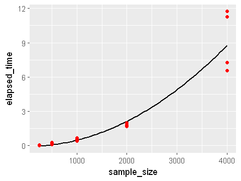

```r
options(repr.plot.width=4, repr.plot.height=3)
ggplot(SS, aes(sample_size, elapsed_time)) +
geom_smooth(method = "lm", formula = y ~ I(x^2), size = 0.7, se = F, color = "black")+
geom_point(color = "red")
```

One could follow same steps for quick_sort. It is a little bir trickier.

# 4 Statistics and Sorting

Statistics and sorting meet under the umberalla of *Order Statistic*. [Here](https://onlinecourses.science.psu.edu/stat414/node/230) you can update your knowledge in Order Statistic.

**Motivational Example:**  
Suppose you are working in a canned food company. And you want to control the amount of toxicity in a canned tomato. You know that after 200 mg/kg of tin, food is considered toxic. Suppose they send you 10 samples everyday from storage units. You repeat this experiment for 3 weeks. Here is your data:

```r
X =matrix(c(76.23,	28.64,	200.81,	73.51,	70.58,	57.6,	88.84,	98.24,	66.7,	110.6,
            117.33,	189.78,	111.71,	101.76,	197.28,	58.58,	16.69,	109.91,	86.57,	14.2,
            10.85,	83.02,	190.35,	192.02,	84.11,	122.55,	107.95,	201.95,	20.49,	17.98,
            104.27,	98.81,	156.11,	134.26,	82.11,	82.15,	87.6,	49.24,	110.72,	148.99,
            91.97,	147.96,	8.5,	191.8,	8.72,	136.88,	84.87,	76.55,	116.02,	70.81,
            96.26,	186.83,	87.95,	87.72,	147.84,	122.29,	116.31,	111.1,	76.85,	19.48,
            15.28,	87.65,	22.34,	101.2,	10.72,	18.6,	91.37,	124.03,	115.37,	17.91,
            95.08,	93.17,	84.87,	20.05,	93.1,	84.46,	72.08,	62.95,	119.52,	109.51,
            87.09,	9.26,	91.61,	9.38,	22.59,	17.39,	120.4,	201.3,	94.53,	73.39,
            199.39,	15.93,	55.29,	13.5,	142.49,	91.14,	67.58,	60.42,	12.29,	193.06,
            112.36,	195.07,	92.75,	77.23,	126.86,	202.79,	121.25,	71.96,	130.11,	15.26,
            118.17,	57.65,	195.93,	89.27,	200.47,	81.65,	78.17,	70.2,	79.58,	98.38,
            18.91,	96.26,	18.88,	109.09,	87.77,	8.63,	70.96,	70.86,	11.09,	91.39,
            199.43,	14.02,	95.2,	127.3,	5.64,	16.78,	192.15,	78.3,	63.04,	93.42,
            107.07,	110.08,	97.59,	103.5,	14.55,	10.02,	139.69,	115.04,	198.96,	103.49,
            76.77,	20.76,	16.59,	103.49,	112.72,	86.9,	68.32,	97.37,	26.43,	205.31,
            104.17,	69.95,	98.83,	99.48,	44.41,	78.78,	197.48,	86.91,	69.88,	78.65,
            81.07,	108.84,	151.33,	118.1,	113.35,	96.5,	61.34,	14.24,	203.21,	139.56,
            101.45,	24.6,	113.7,	136.57,	11.09,	197.61,	91.38,	120.81,	111.18,	201.62,
            77.23,	73.79,	112.19,	96.02,	86.49,	200.91,	69.28,	199.2,	23.94,	96.83,
            200.75,	113.51,	25.64,	112.45,	51.05,	15.77,	135.42,	194.81,	193.05,	71.34),
            21, 10, byrow = T)

rownames(X) = paste("day", 1:21, sep = "")
```

```r
X
```

| day1 | 76.23 | 28.64 | 200.81 | 73.51 | 70.58 | 57.60 | 88.84 | 98.24 | 66.70 | 110.60 |
| --- | --- | --- | --- | --- | --- | --- | --- | --- | --- | --- |
| day2 | 117.33 | 189.78 | 111.71 | 101.76 | 197.28 | 58.58 | 16.69 | 109.91 | 86.57 | 14.20 |
| day3 | 10.85 | 83.02 | 190.35 | 192.02 | 84.11 | 122.55 | 107.95 | 201.95 | 20.49 | 17.98 |
| day4 | 104.27 | 98.81 | 156.11 | 134.26 | 82.11 | 82.15 | 87.60 | 49.24 | 110.72 | 148.99 |
| day5 | 91.97 | 147.96 | 8.50 | 191.80 | 8.72 | 136.88 | 84.87 | 76.55 | 116.02 | 70.81 |
| day6 | 96.26 | 186.83 | 87.95 | 87.72 | 147.84 | 122.29 | 116.31 | 111.10 | 76.85 | 19.48 |
| day7 | 15.28 | 87.65 | 22.34 | 101.20 | 10.72 | 18.60 | 91.37 | 124.03 | 115.37 | 17.91 |
| day8 | 95.08 | 93.17 | 84.87 | 20.05 | 93.10 | 84.46 | 72.08 | 62.95 | 119.52 | 109.51 |
| day9 | 87.09 | 9.26 | 91.61 | 9.38 | 22.59 | 17.39 | 120.40 | 201.30 | 94.53 | 73.39 |
| day10 | 199.39 | 15.93 | 55.29 | 13.50 | 142.49 | 91.14 | 67.58 | 60.42 | 12.29 | 193.06 |
| day11 | 112.36 | 195.07 | 92.75 | 77.23 | 126.86 | 202.79 | 121.25 | 71.96 | 130.11 | 15.26 |
| day12 | 118.17 | 57.65 | 195.93 | 89.27 | 200.47 | 81.65 | 78.17 | 70.20 | 79.58 | 98.38 |
| day13 | 18.91 | 96.26 | 18.88 | 109.09 | 87.77 | 8.63 | 70.96 | 70.86 | 11.09 | 91.39 |
| day14 | 199.43 | 14.02 | 95.20 | 127.30 | 5.64 | 16.78 | 192.15 | 78.30 | 63.04 | 93.42 |
| day15 | 107.07 | 110.08 | 97.59 | 103.50 | 14.55 | 10.02 | 139.69 | 115.04 | 198.96 | 103.49 |
| day16 | 76.77 | 20.76 | 16.59 | 103.49 | 112.72 | 86.90 | 68.32 | 97.37 | 26.43 | 205.31 |
| day17 | 104.17 | 69.95 | 98.83 | 99.48 | 44.41 | 78.78 | 197.48 | 86.91 | 69.88 | 78.65 |
| day18 | 81.07 | 108.84 | 151.33 | 118.10 | 113.35 | 96.50 | 61.34 | 14.24 | 203.21 | 139.56 |
| day19 | 101.45 | 24.60 | 113.70 | 136.57 | 11.09 | 197.61 | 91.38 | 120.81 | 111.18 | 201.62 |
| day20 | 77.23 | 73.79 | 112.19 | 96.02 | 86.49 | 200.91 | 69.28 | 199.20 | 23.94 | 96.83 |
| day21 | 200.75 | 113.51 | 25.64 | 112.45 | 51.05 | 15.77 | 135.42 | 194.81 | 193.05 | 71.34 |

Here is the histogram of the mean measurement in each day:

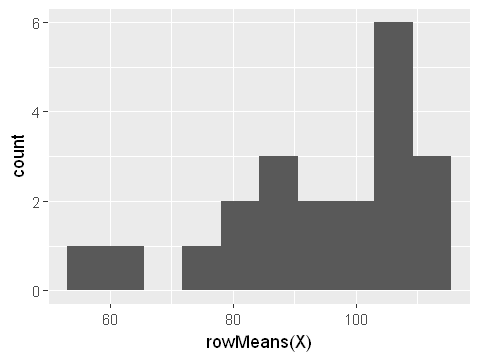

```r
qplot(rowMeans(X), geom="histogram", bins = 10)
```

Most of the days the mean value is around 100 mg. However the distribution of mean value in each day is not practical for infering maximum toxicity level. We want to take action for extreme toxicity levels. Therefore we need to get the distribution of maximum toxicity level for each sample. To do that, we sort the values of each day.

```r
Sorted = t(apply(X, 1, quick_sort))
Sorted
```

| day1 | 28.64 | 57.60 | 66.70 | 70.58 | 73.51 | 76.23 | 88.84 | 98.24 | 110.60 | 200.81 |
| --- | --- | --- | --- | --- | --- | --- | --- | --- | --- | --- |
| day2 | 14.20 | 16.69 | 58.58 | 86.57 | 101.76 | 109.91 | 111.71 | 117.33 | 189.78 | 197.28 |
| day3 | 10.85 | 17.98 | 20.49 | 83.02 | 84.11 | 107.95 | 122.55 | 190.35 | 192.02 | 201.95 |
| day4 | 49.24 | 82.11 | 82.15 | 87.60 | 98.81 | 104.27 | 110.72 | 134.26 | 148.99 | 156.11 |
| day5 | 8.50 | 8.72 | 70.81 | 76.55 | 84.87 | 91.97 | 116.02 | 136.88 | 147.96 | 191.80 |
| day6 | 19.48 | 76.85 | 87.72 | 87.95 | 96.26 | 111.10 | 116.31 | 122.29 | 147.84 | 186.83 |
| day7 | 10.72 | 15.28 | 17.91 | 18.60 | 22.34 | 87.65 | 91.37 | 101.20 | 115.37 | 124.03 |
| day8 | 20.05 | 62.95 | 72.08 | 84.46 | 84.87 | 93.10 | 93.17 | 95.08 | 109.51 | 119.52 |
| day9 | 9.26 | 9.38 | 17.39 | 22.59 | 73.39 | 87.09 | 91.61 | 94.53 | 120.40 | 201.30 |
| day10 | 12.29 | 13.50 | 15.93 | 55.29 | 60.42 | 67.58 | 91.14 | 142.49 | 193.06 | 199.39 |
| day11 | 15.26 | 71.96 | 77.23 | 92.75 | 112.36 | 121.25 | 126.86 | 130.11 | 195.07 | 202.79 |
| day12 | 57.65 | 70.20 | 78.17 | 79.58 | 81.65 | 89.27 | 98.38 | 118.17 | 195.93 | 200.47 |
| day13 | 8.63 | 11.09 | 18.88 | 18.91 | 70.86 | 70.96 | 87.77 | 91.39 | 96.26 | 109.09 |
| day14 | 5.64 | 14.02 | 16.78 | 63.04 | 78.30 | 93.42 | 95.20 | 127.30 | 192.15 | 199.43 |
| day15 | 10.02 | 14.55 | 97.59 | 103.49 | 103.50 | 107.07 | 110.08 | 115.04 | 139.69 | 198.96 |
| day16 | 16.59 | 20.76 | 26.43 | 68.32 | 76.77 | 86.90 | 97.37 | 103.49 | 112.72 | 205.31 |
| day17 | 44.41 | 69.88 | 69.95 | 78.65 | 78.78 | 86.91 | 98.83 | 99.48 | 104.17 | 197.48 |
| day18 | 14.24 | 61.34 | 81.07 | 96.50 | 108.84 | 113.35 | 118.10 | 139.56 | 151.33 | 203.21 |
| day19 | 11.09 | 24.60 | 91.38 | 101.45 | 111.18 | 113.70 | 120.81 | 136.57 | 197.61 | 201.62 |
| day20 | 23.94 | 69.28 | 73.79 | 77.23 | 86.49 | 96.02 | 96.83 | 112.19 | 199.20 | 200.91 |
| day21 | 15.77 | 25.64 | 51.05 | 71.34 | 112.45 | 113.51 | 135.42 | 193.05 | 194.81 | 200.75 |

As one can see, the last column of above matrix is the vector of maximum values for each sample. This will give us the sample of maximum toxicity level for a given day.

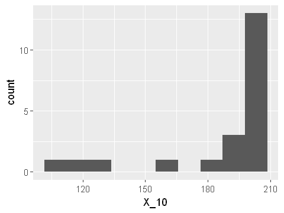

```r
X_10 = Sorted[,10]
qplot(X_10, geom="histogram", bins = 10)
```

As one can see it is accumulated around 200 mg. Probably there is a problem in production line, packaging units or warehouse. Company should take immediate action.